# Stat 324 HW8: ANOVA and Regression

Devin Johnson, Dis. 313

December 3, 2018

## Problem 1

```r
# Data for problem 1
t1 = c(63, 54, 69, 50, 72)
t2 = c(45, 60, 40, 56)
t3 = c(31, 40, 45, 25, 23, 28)
df = data.frame(treatment=c(rep("t1",5), rep("t2", 4), rep("t3", 6)), Data=c(t1, t2, t3))
anova_obj = aov(Data~treatment, data=df)
```

**–1A: Graph–**

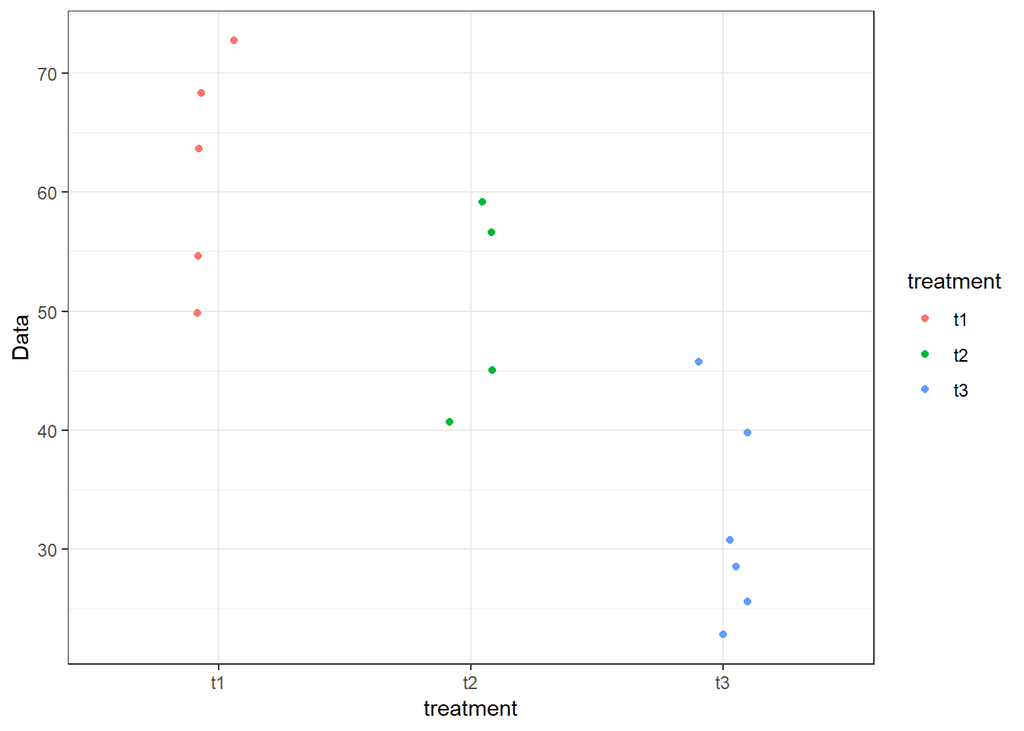

```r
require(ggplot2)
ggplot(data=df, aes(x=treatment, y=Data, color=treatment))+  geom_jitter(width=0.1)+  theme_bw()
```

I’m using a dot plot to get a combined picture of all groups. It tells me the approximate variance of the data.

**–1B: Summary Stats–**

```r
# Basic stats
xbar_1 = mean(t1); xbar_2 = mean(t2); xbar_3 = mean(t3)
n_1 = length(t1); n_2 = length(t2); n_3 = length(t3)
sd_1 = sd(t1); sd_2 = sd(t2); sd_3 = sd(t3)
xbar_grand = mean(df$Data); n_grand = length(df$Data); k = 3
```

**–1C: ANOVA Calculations/Table–**

```r
# MSE
sse = 0
for (val in t1){
  sse = sse + (val-xbar_1)^2
}
for (val in t2){
  sse = sse + (val-xbar_2)^2
}
for (val in t3){
  sse = sse + (val-xbar_3)^2
}
mse = sse/(n_grand - k)

# MST
sst = n_1*(xbar_1 - xbar_grand)^2 + n_2*(xbar_2 - xbar_grand)^2 + n_3*(xbar_3 - xbar_grand)^2
mst = sst/(k - 1)

# F Stat
fstat = mst / mse

table = data.frame(
   source = c("Treatment", "Error", "Total"),
   df = c(k-1, n_grand-k, n_grand-1),
   ss = c(sst, sse, sse+sst),
   ms = c(mst, mse, "-"),
   f = c(fstat, "-", "-"),
   pval = c("<.001", "-", "-"),
   stringsAsFactors = FALSE
)
print(table)
```

```
##      source df       ss               ms               f  pval
## 1 Treatment  2 2456.983 1228.49166666667 14.772182975099 <.001
## 2     Error 12  997.950          83.1625               -     -
## 3     Total 14 3454.933                -               -     -
```

```r
# Check with R
summary(anova_obj)
```

```
##             Df Sum Sq Mean Sq F value   Pr(>F)
## treatment    2   2457  1228.5   14.77 0.000581 ***
## Residuals   12    998    83.2
## ---
## Signif. codes:  0 '***' 0.001 '**' 0.01 '*' 0.05 '.' 0.1 ' ' 1
```

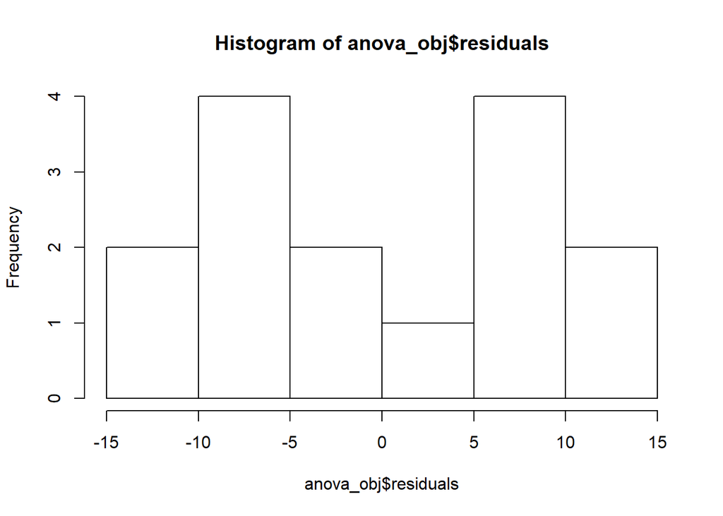

```r
hist(anova_obj$residuals)
```

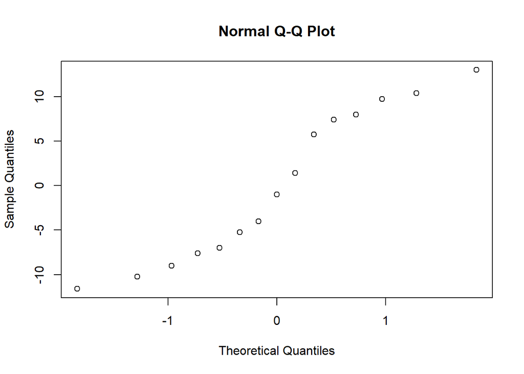

```r
qqnorm(anova_obj$residuals)
```

**–1E: Test Conclusions–**  
Since p<0.001 from F table, we can say that at least two groups are significantly different. We can make pairwise confidence intervals to test further.

**–1F: Tukey CI–**

```r
tukey_mult = qtukey(p=(1-0.05), nmeans = 3, df = 12)/sqrt(2)
t1t2_low = abs(xbar_1 - xbar_2) - (tukey_mult*sqrt(mse*((1/n_1) + 1/(n_2))))
t1t2_high = abs(xbar_1 - xbar_2) + (tukey_mult*sqrt(mse*((1/n_1) + 1/(n_2))))
t1t3_low = abs(xbar_1 - xbar_3) - (tukey_mult*sqrt(mse*((1/n_1) + 1/(n_3))))
t1t3_high = abs(xbar_1 - xbar_3) + (tukey_mult*sqrt(mse*((1/n_1) + 1/(n_3))))
t2t3_low = abs(xbar_2 - xbar_3) - (tukey_mult*sqrt(mse*((1/n_2) + 1/(n_3))))
t2t3_high = abs(xbar_2 - xbar_3) + (tukey_mult*sqrt(mse*((1/n_2) + 1/(n_3))))

paste("T1 vs T2:", "(", t1t2_low, ",",  t1t2_high, ")", sep="")
```

```
## [1] "T1 vs T2:(-4.97050734346403,27.670507343464)"
```

```r
paste("T1 vs T3:", "(", t1t3_low, ",",  t1t3_high, ")", sep="")
```

```
## [1] "T1 vs T3:(14.867952395395,44.332047604605)"
```

```r
paste("T2 vs T3:", "(", t2t3_low, ",",  t2t3_high, ")", sep="")
```

```
## [1] "T2 vs T3:(2.5455844865663,33.9544155134337)"
```

We can label as follows: t3 = A, t2 = B, t1 = B since the differences between t2 and t3 and t1 and t3 are signifcant.

**–1G: Bonferroni Multiplier–**

```r
bonf_mult = qt(p=(0.05/6), df = 12 , lower.tail = FALSE)
print(tukey_mult)
```

```
## [1] 2.667864
```

```r
print(bonf_mult)
```

```
## [1] 2.779473
```

```r
print(abs(tukey_mult-bonf_mult))
```

```
## [1] 0.1116094
```

**–1H: Kruskal-Wallis and Wilcoxon–**

```r
kruskal.test(Data~treatment, data=df)
```

```
##
##  Kruskal-Wallis rank sum test
##
## data:  Data by treatment
## Kruskal-Wallis chi-squared = 9.8535, df = 2, p-value = 0.00725
```

```r
wilcox.test(t1, t2)
```

```
##
##  Wilcoxon rank sum test
##
## data:  t1 and t2
## W = 16, p-value = 0.1905
## alternative hypothesis: true location shift is not equal to 0
```

```r
wilcox.test(t1, t3)
```

```
##
##  Wilcoxon rank sum test
##
## data:  t1 and t3
## W = 30, p-value = 0.004329
## alternative hypothesis: true location shift is not equal to 0
```

```r
wilcox.test(t2, t3)
```

```
##
##  Wilcoxon rank sum test with continuity correction
##
## data:  t2 and t3
## W = 22, p-value = 0.04157
## alternative hypothesis: true location shift is not equal to 0
```

Less strong evidence against null. When comparing with bonferroni adjustment, the pairwise comparison between t1 and t3 is significant.

## Problem 2

**–2A: ANOVA Table–**

```r
# Data for problem 2
xbar_1 = 39.1; xbar_2 = 29.9; xbar_3 = 45.9
n_1 = 9; n_2 = 8; n_3 = 10
sd_1 = sqrt(24.6); sd_2 = sqrt(16.4); sd_3 = sqrt(10.3)
xbar_grand = (xbar_1 + xbar_2 + xbar_3)/3 ; n_grand = n_1 + n_2 + n_3; k = 3

# MSE (how to get from just standard deviation???)
sse = 404.3672
mse = sse/(n_grand - k)

# MST
sst = n_1*(xbar_1 - xbar_grand)^2 + n_2*(xbar_2 - xbar_grand)^2 + n_3*(xbar_3 - xbar_grand)^2
mst = sst/(k - 1)

# F Stat
fstat = mst / mse

table = data.frame(
   source = c("Treatment", "Error", "Total"),
   df = c(k-1, n_grand-k, n_grand-1),
   ss = c(sst, sse, sse+sst),
   ms = c(mst, mse, "-"),
   f = c(fstat, "-", "-"),
   pval = c("<.000", "-", "-"),
   stringsAsFactors = FALSE
)
print(table)
```

```
##      source df        ss               ms                f  pval
## 1 Treatment  2 1147.8400           573.92 34.0632969241818 <.000
## 2     Error 24  404.3672 16.8486333333333                -     -
## 3     Total 26 1552.2072                -                -     -
```

**–2B: F Test–** The result from part A is signifcant, so we make pairwise confidence intervals. (TukeyHSD)

```r
tukey_mult = qtukey(p=(1-0.05), nmeans = 3, df = 24)/sqrt(2)
t1t2_low = abs(xbar_1 - xbar_2) - (tukey_mult*sqrt(mse*((1/n_1) + 1/(n_2))))
t1t2_high = abs(xbar_1 - xbar_2) + (tukey_mult*sqrt(mse*((1/n_1) + 1/(n_2))))
t1t3_low = abs(xbar_1 - xbar_3) - (tukey_mult*sqrt(mse*((1/n_1) + 1/(n_3))))
t1t3_high = abs(xbar_1 - xbar_3) + (tukey_mult*sqrt(mse*((1/n_1) + 1/(n_3))))
t2t3_low = abs(xbar_2 - xbar_3) - (tukey_mult*sqrt(mse*((1/n_2) + 1/(n_3))))
t2t3_high = abs(xbar_2 - xbar_3) + (tukey_mult*sqrt(mse*((1/n_2) + 1/(n_3))))

paste("T1 vs T2:", "(", t1t2_low, ",",  t1t2_high, ")", sep="")
```

```
## [1] "T1 vs T2:(4.21908616139167,14.1809138386083)"
```

```r
paste("T1 vs T3:", "(", t1t3_low, ",",  t1t3_high, ")", sep="")
```

```
## [1] "T1 vs T3:(2.0901577361986,11.5098422638014)"
```

```r
paste("T2 vs T3:", "(", t2t3_low, ",",  t2t3_high, ")", sep="")
```

```
## [1] "T2 vs T3:(11.1376963628594,20.8623036371406)"
```

When assigning letters to the results we get: A, B, and C for T1, T2, and T3 respectively since diferences between all groups are significant

## Problem 3

**–3A: Plot–**

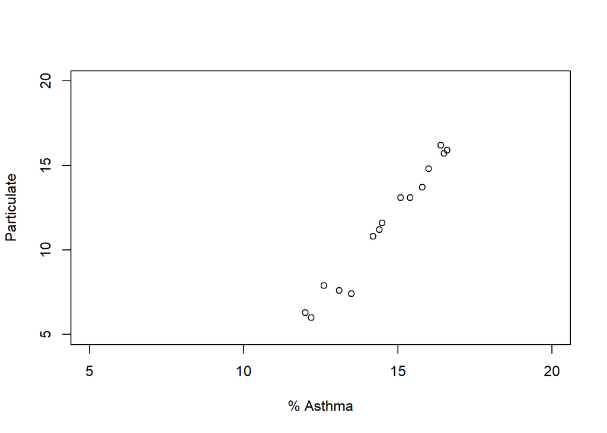

```r
particulate = c(11.6, 15.9, 15.7, 7.9, 6.3, 13.7, 13.1, 10.8, 6.0, 7.6, 14.8, 7.4, 16.2, 13.1, 11.2)
asthma = c(14.5, 16.6, 16.5, 12.6, 12.0, 15.8, 15.1, 14.2, 12.2, 13.1, 16.0, 13.5, 16.4, 15.4, 14.4)
plot(particulate~asthma, ylab="Particulate", xlab="% Asthma", ylim=c(5, 20), xlim=c(5, 20))
```

Seems to be a strong positive linear correlation between particulates and asthma in the observed data.

**–3B: Correlation Coefficient–**

```r
print(sum((particulate-mean(particulate))*(asthma-mean(asthma)))/(sqrt(sum((particulate-mean(particulate))^2)*sum((asthma-mean(asthma))^2))))
```

```
## [1] 0.9854127
```

```r
cor(particulate, asthma)
```

```
## [1] 0.9854127
```

**–3C: Model–**

```r
beta_1 = cor(particulate, asthma) * sd(asthma) / sd(particulate)
beta_0 = mean(asthma) - (beta_1*mean(particulate))
paste("Slope: ",beta_1, sep ="")
```

```
## [1] "Slope: 0.433126806200193"
```

```r
paste("Intercept: ",beta_0, sep = "")
```

```
## [1] "Intercept: 9.60702520652713"
```

Slope and intercept suggest that each time particulate increased, there will be an increase of about 0.43% in asthma rate.

**–3D: Graphical Interpretation–**

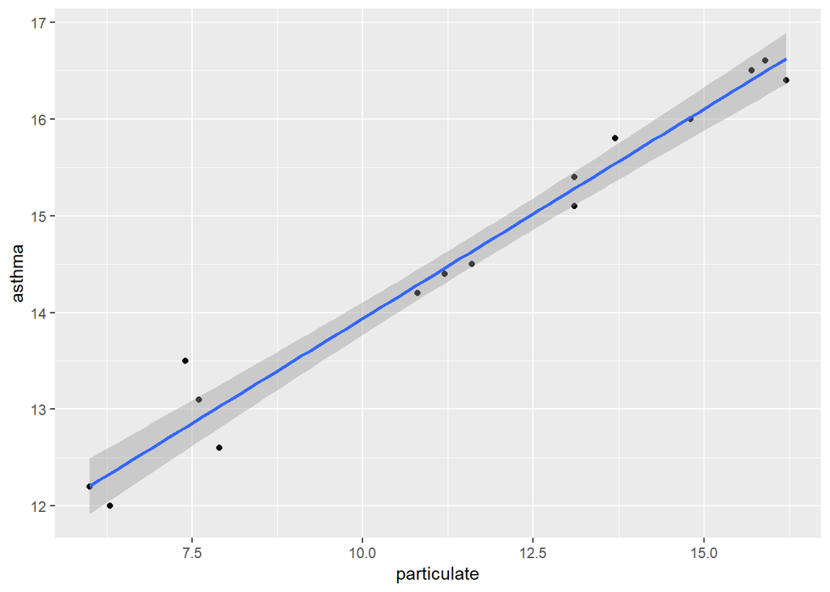

```r
mod = lm(asthma~particulate)
require(ggplot2)
ggplot(data=data.frame(particulate, asthma), aes(x=particulate, y=asthma))+
  geom_point()+
  geom_smooth(method="lm", se=TRUE)
```

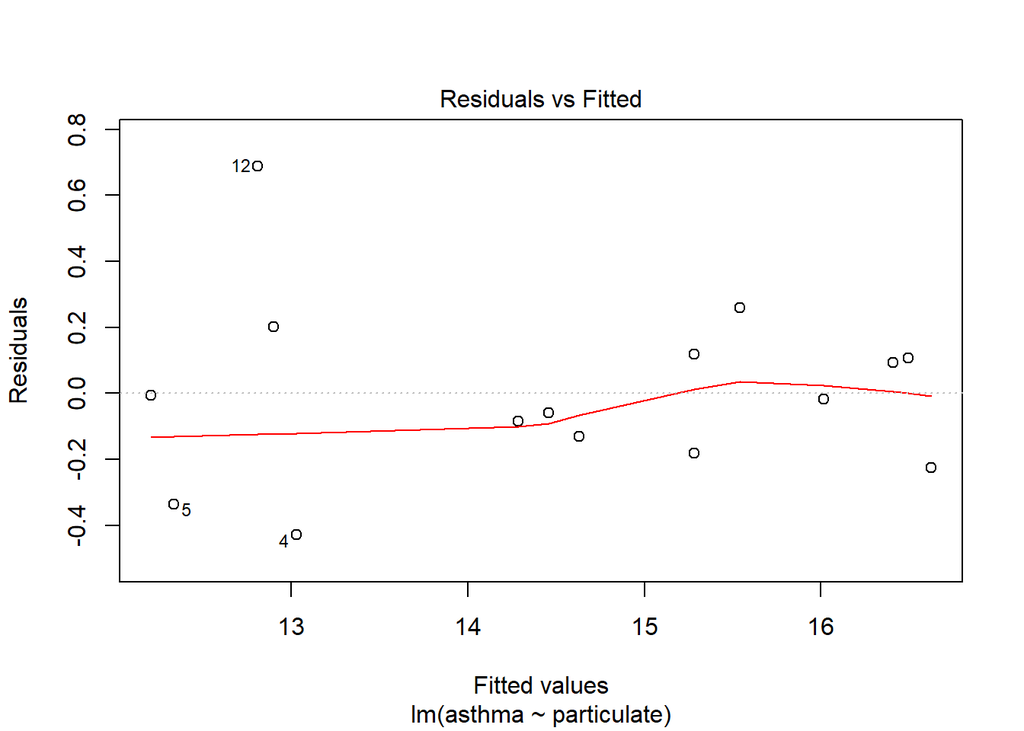

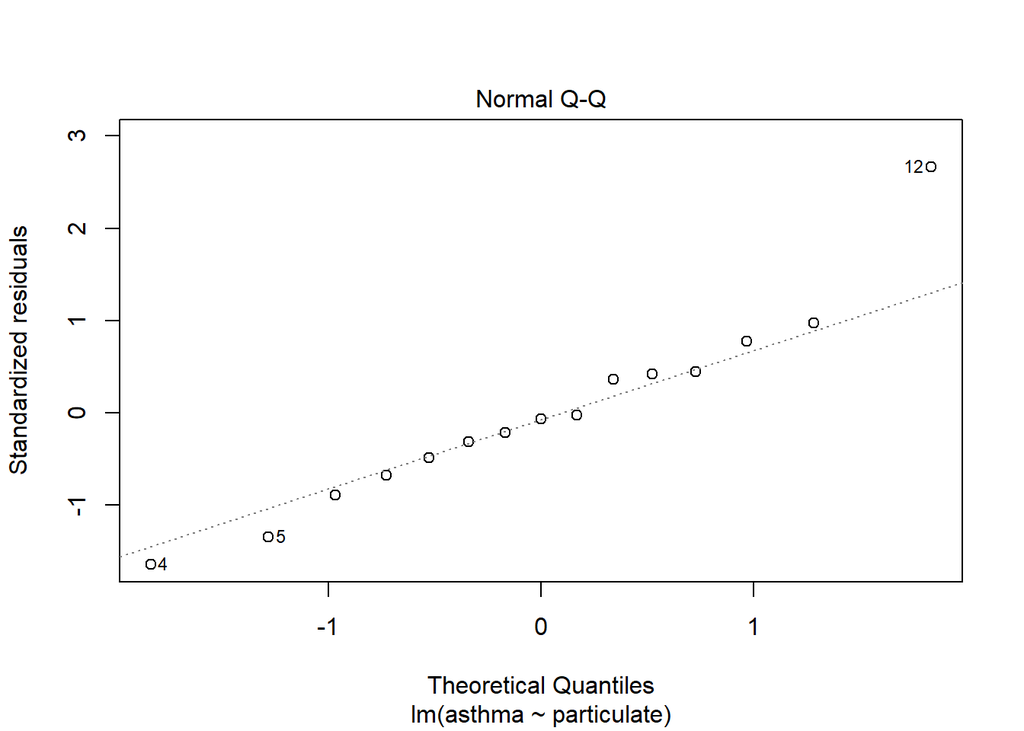

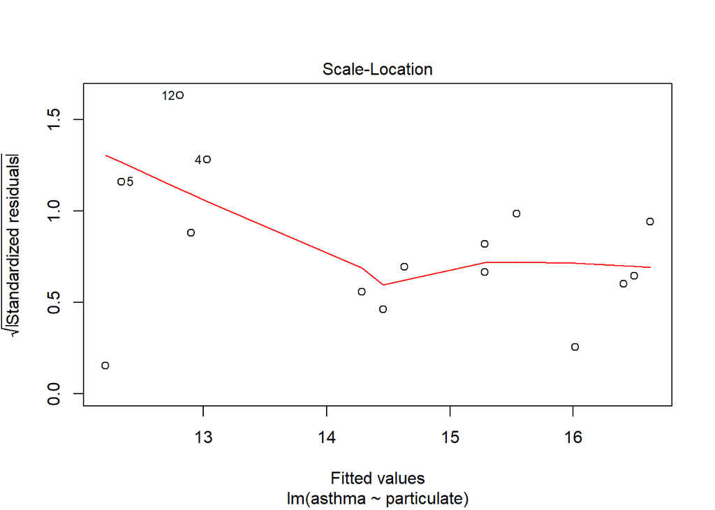

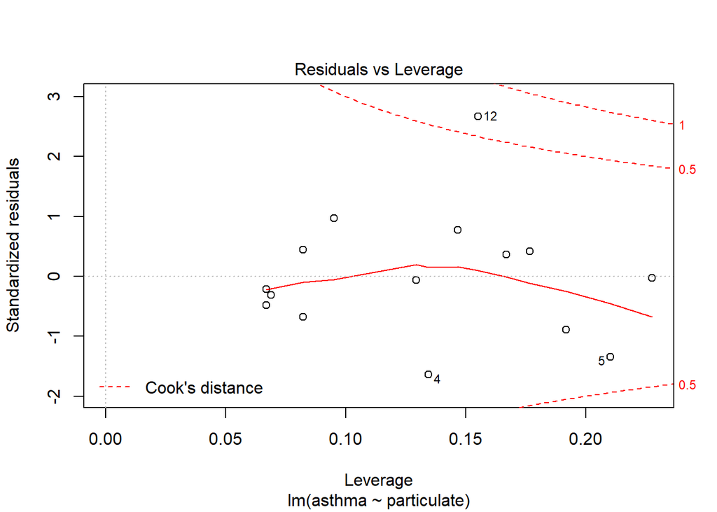

```r
plot(mod)
```

Considering assumptions that we can tell from the model, there are no clear deviations from constant variance or curvature of residuals.

**–3E/F: Test Slope and R^2–**  
$H_o: \beta_1 = 0$  
$H_a: \beta_1 \neq 0$  
$\alpha = 0.5$

```r
summary(mod)
```

```
##
## Call:
## lm(formula = asthma ~ particulate)
##
## Residuals:
##     Min      1Q  Median      3Q     Max
## -0.4287 -0.1561 -0.0173  0.1126  0.6878
##
## Coefficients:
##             Estimate Std. Error t value          Pr(>|t|)
## (Intercept)  9.60703    0.24774   38.78 0.000000000000008 ***
## particulate  0.43313    0.02075   20.88 0.000000000022081 ***
## ---
## Signif. codes:  0 '***' 0.001 '**' 0.01 '*' 0.05 '.' 0.1 ' ' 1
##
## Residual standard error: 0.2804 on 13 degrees of freedom
## Multiple R-squared:  0.971,  Adjusted R-squared:  0.9688
## F-statistic: 435.9 on 1 and 13 DF,  p-value: 0.00000000002208
```

P-value is extremely significant so slop is highly significant. We can’t say that increased particulate causes increased asthma. R^2 = 0.97 so regression on particulate accounts for ~97.1% of variation in asthma.

**–3G/H/I/J: Confidence Intervals–**

```r
# G
se = 0.28*sqrt(1 + 1/15 + (13-11.42)^2/(14-13.05))
upper = 15.2 + 0.63
lower = 15.2 - 0.63
paste("CI G:", "(", lower, ",",  upper, ")", sep="")
```

```
## [1] "CI G:(14.57,15.83)"
```

```r
# H
se = 0.28*sqrt(1/15 + (10-11.42)^2/(14 + 13.05))
upper = 13.91 + 0.17
lower = 13.91 - 0.17
paste("CI H:", "(", lower, ",",  upper, ")", sep="")
```

```
## [1] "CI H:(13.74,14.08)"
```

```r
# I
# 3ppm is outside values of x user to build the model. Therefore using a confidence interval would not yield reliable results.

# J
# Since there is a smaller standard error, the interval at x=12 is narrower (it's closer to xbar = 11.42)
```

**–4A: Least Squares Estimates–**

```r
b_1 = 10360/11000
b_0 = 47.91 - (b_1 * 50)

print(b_0)
```

```
## [1] 0.8190909
```

```r
print(b_1)
```

```
## [1] 0.9418182
```

**–4B: Hypothesis Test–**  
$H_0: \beta_1 = 1$  
$H_a: \beta_1 \neq 1$  
$\alpha = .01$

```r
sse = 11.67
mse = sse/9
t = (b_1 - 1) / (sqrt(mse/(11000)))
print(t)
```

```
## [1] -5.358824
```

```r
2*pt(-abs(t),df = 9)
```

```
## [1] 0.0004570197
```

There is strong evidence against the null hypothesis that $\beta_1 = 1$